# ds

## cpagomiscuentas

| Feature | Result |
| --- | --- |
| Variable type | integer |
| Number of missing obs. | 0 (0 %) |
| Number of unique values | 84 |
| Median | 1 |
| 1st and 3rd quartiles | 0; 4 |
| Min. and max. | 0; 290 |

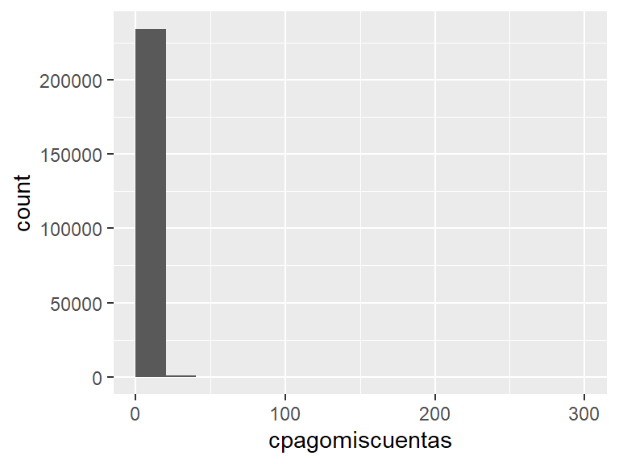

- Note that the following possible outlier values were detected: “31”, “32”, “33”, “34”, “35”, “36”, “37”, “38”, “39”, “40” (43 additional values omitted).

## mpagomiscuentas

| Feature | Result |
| --- | --- |
| Variable type | numeric |
| Number of missing obs. | 0 (0 %) |
| Number of unique values | 104141 |
| Median | 143.85 |
| 1st and 3rd quartiles | 0; 10548.66 |
| Min. and max. | 0; 42229617.15 |

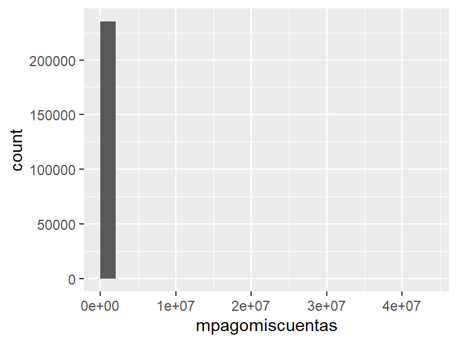

- Note that the following possible outlier values were detected: “303719.34”, “303881.06”, “304631.67”, “304696.62”, “304699.73”, “304759.76”, “305012.34”, “305021.73”, “305133.13”, “305534.04” (1023 additional values omitted).

## ccajeros_propios_descuentos

- The variable only takes one (non-missing) value: “0”. The variable contains 0 % missing observations.

## mcajeros_propios_descuentos

- The variable only takes one (non-missing) value: “0”. The variable contains 0 % missing observations.

## ctarjeta_visa_descuentos

- The variable only takes one (non-missing) value: “0”. The variable contains 0 % missing observations.

## mtarjeta_visa_descuentos

- The variable only takes one (non-missing) value: “0”. The variable contains 0 % missing observations.

## ctarjeta_master_descuentos

- The variable only takes one (non-missing) value: “0”. The variable contains 0 % missing observations.

## mtarjeta_master_descuentos

- The variable only takes one (non-missing) value: “0”. The variable contains 0 % missing observations.

## ccomisiones_mantenimiento

| Feature | Result |
| --- | --- |
| Variable type | integer |
| Number of missing obs. | 0 (0 %) |
| Number of unique values | 21 |
| Median | 0 |
| 1st and 3rd quartiles | 0; 1 |
| Min. and max. | 0; 48 |

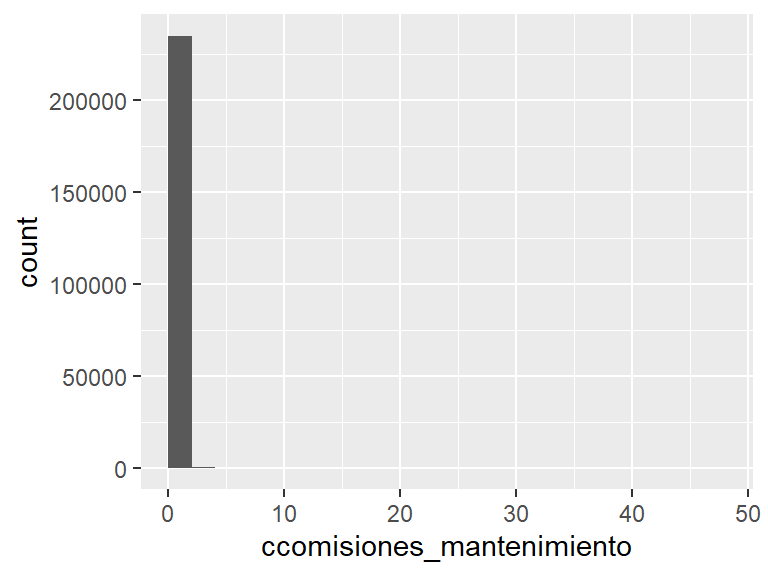

- Note that the following possible outlier values were detected: “38”, “48”.

## mcomisiones_mantenimiento

| Feature | Result |
| --- | --- |
| Variable type | numeric |
| Number of missing obs. | 0 (0 %) |
| Number of unique values | 489 |
| Median | 0 |
| 1st and 3rd quartiles | 0; 680.72 |
| Min. and max. | -18336.09; 7499.74 |

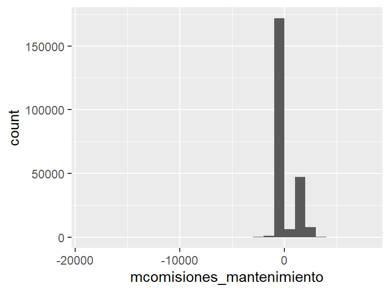

- Note that the following possible outlier values were detected: “-18336.09”, “-14068.99”, “-13097.21”, “-11724.16”, “-11539.47”, “-9616.23”, “-9379.32”, “-8600.96”, “-8168.75”, “-7858.32” (75 additional values omitted).

## ccomisiones_otras

| Feature | Result |
| --- | --- |
| Variable type | integer |
| Number of missing obs. | 0 (0 %) |
| Number of unique values | 189 |
| Median | 8 |
| 1st and 3rd quartiles | 6; 12 |
| Min. and max. | 0; 274 |

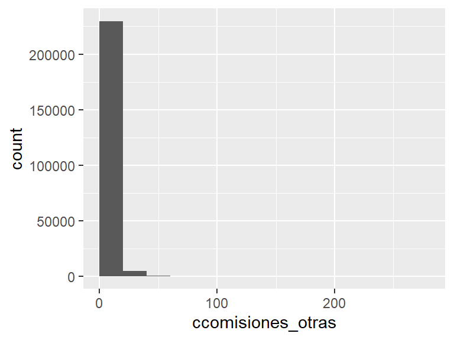

- Note that the following possible outlier values were detected: “22”, “23”, “24”, “25”, “26”, “27”, “28”, “29”, “30”, “31” (157 additional values omitted).

## mcomisiones_otras

| Feature | Result |
| --- | --- |
| Variable type | numeric |
| Number of missing obs. | 0 (0 %) |
| Number of unique values | 146728 |
| Median | 703.68 |
| 1st and 3rd quartiles | 241.04; 1585.5 |
| Min. and max. | -243252.69; 264726.31 |

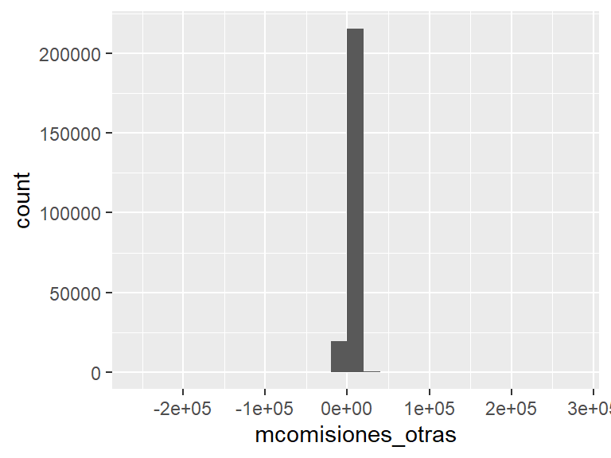

- Note that the following possible outlier values were detected: “-243252.69”, “-130560.93”, “-44231.6”, “-38800.92”, “-26524.46”, “-25383.07”, “-24273.06”, “-22151.71”, “-21710.84”, “-16730.28” (7102 additional values omitted).

## cforex

| Feature | Result |
| --- | --- |
| Variable type | integer |
| Number of missing obs. | 0 (0 %) |
| Number of unique values | 14 |
| Median | 0 |
| 1st and 3rd quartiles | 0; 1 |
| Min. and max. | 0; 19 |

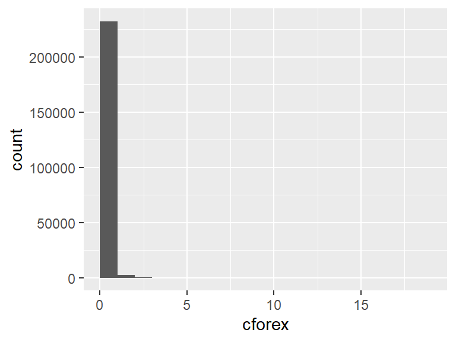

## cforex_buy

| Feature | Result |
| --- | --- |
| Variable type | integer |
| Number of missing obs. | 0 (0 %) |
| Number of unique values | 12 |
| Median | 0 |
| 1st and 3rd quartiles | 0; 0 |
| Min. and max. | 0; 12 |

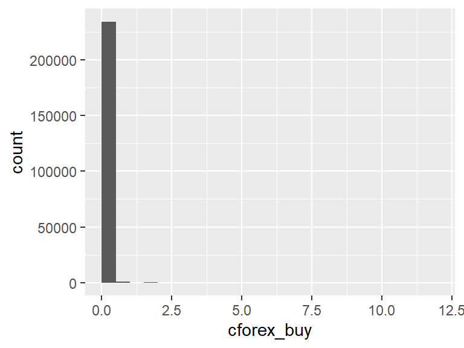

- Note that the following possible outlier values were detected: “1”, “2”, “3”, “4”, “5”, “6”, “7”, “8”, “10”, “11” (1 additional values omitted).

## mforex_buy

| Feature | Result |
| --- | --- |
| Variable type | numeric |
| Number of missing obs. | 0 (0 %) |
| Number of unique values | 450 |
| Median | 0 |
| 1st and 3rd quartiles | 0; 0 |
| Min. and max. | 0; 21060 |

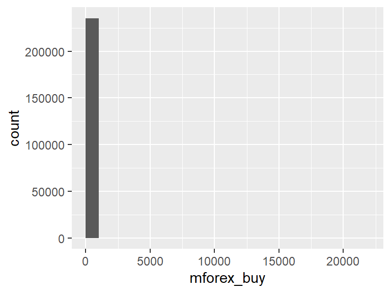

- Note that the following possible outlier values were detected: “0.33”, “1.17”, “1.2”, “1.22”, “1.26”, “1.29”, “1.35”, “1.4”, “1.42”, “1.48” (439 additional values omitted).

## cforex_sell

| Feature | Result |
| --- | --- |
| Variable type | integer |
| Number of missing obs. | 0 (0 %) |
| Number of unique values | 13 |
| Median | 0 |
| 1st and 3rd quartiles | 0; 1 |
| Min. and max. | 0; 19 |

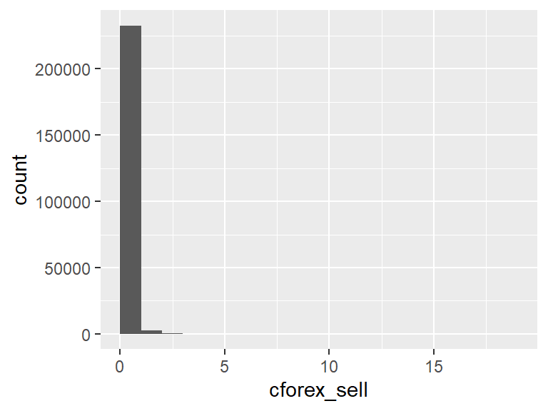

## mforex_sell

| Feature | Result |
| --- | --- |
| Variable type | numeric |
| Number of missing obs. | 0 (0 %) |
| Number of unique values | 681 |
| Median | 0 |
| 1st and 3rd quartiles | 0; 234 |
| Min. and max. | 0; 6660.82 |

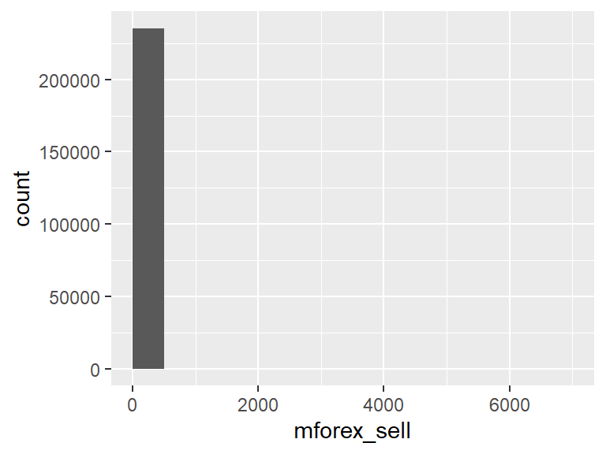

## ctransferencias_recibidas

| Feature | Result |
| --- | --- |
| Variable type | integer |
| Number of missing obs. | 0 (0 %) |
| Number of unique values | 262 |
| Median | 2 |
| 1st and 3rd quartiles | 1; 4 |
| Min. and max. | 0; 9338 |

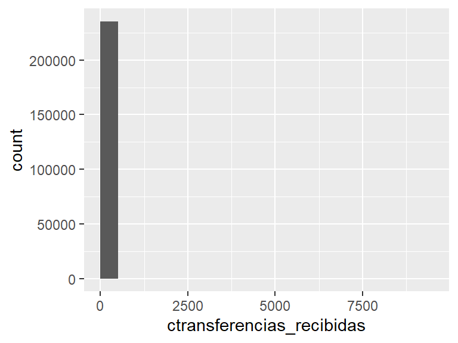

- Note that the following possible outlier values were detected: “17”, “18”, “19”, “20”, “21”, “22”, “23”, “24”, “25”, “26” (235 additional values omitted).

## mtransferencias_recibidas

| Feature | Result |
| --- | --- |
| Variable type | numeric |
| Number of missing obs. | 0 (0 %) |
| Number of unique values | 109094 |
| Median | 33925.91 |
| 1st and 3rd quartiles | 1180.17; 92430 |
| Min. and max. | 0; 665998718.2 |

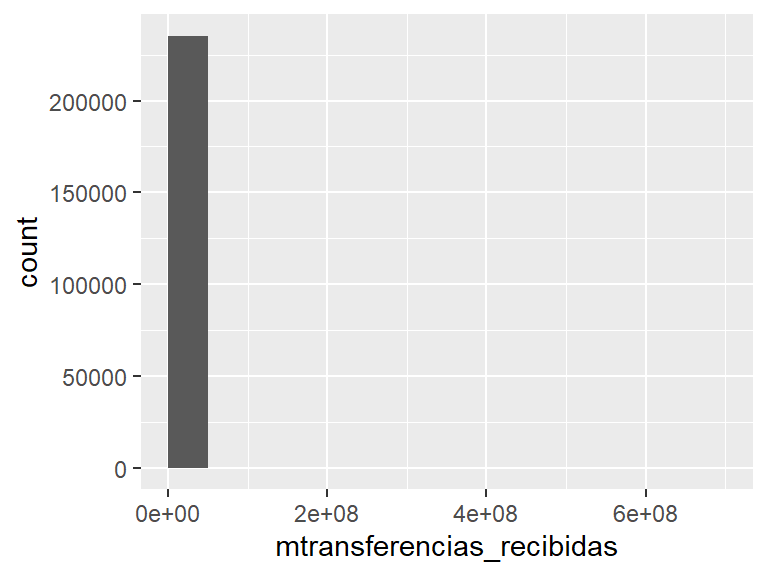

- Note that the following possible outlier values were detected: “568210.5”, “568293.55”, “568384.53”, “568400.88”, “568437”, “568515.78”, “568548.3”, “568737”, “568745.24”, “568899.29” (5927 additional values omitted).

## ctransferencias_emitidas

| Feature | Result |
| --- | --- |
| Variable type | integer |
| Number of missing obs. | 0 (0 %) |
| Number of unique values | 128 |
| Median | 1 |
| 1st and 3rd quartiles | 0; 4 |
| Min. and max. | 0; 365 |

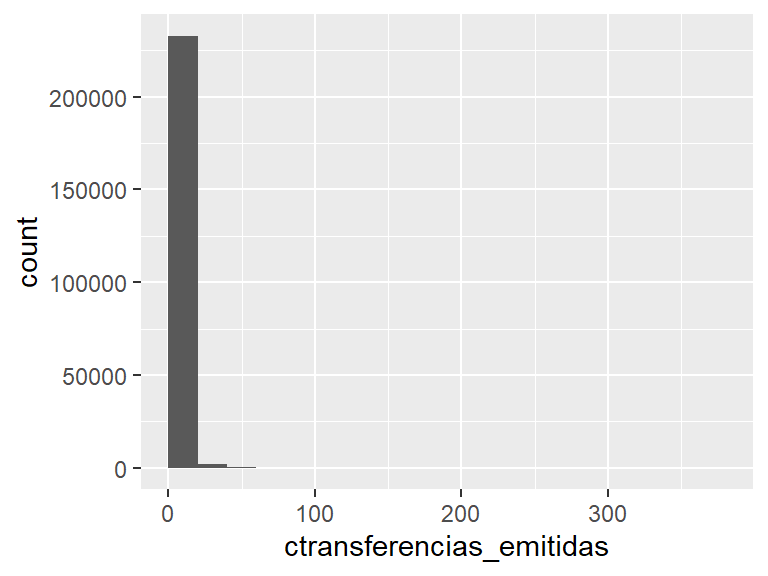

- Note that the following possible outlier values were detected: “41”, “42”, “43”, “44”, “45”, “46”, “47”, “48”, “49”, “50” (77 additional values omitted).

## mtransferencias_emitidas

| Feature | Result |
| --- | --- |
| Variable type | numeric |
| Number of missing obs. | 0 (0 %) |
| Number of unique values | 74479 |
| Median | 6446.7 |
| 1st and 3rd quartiles | 0; 36270 |
| Min. and max. | 0; 72787705.74 |

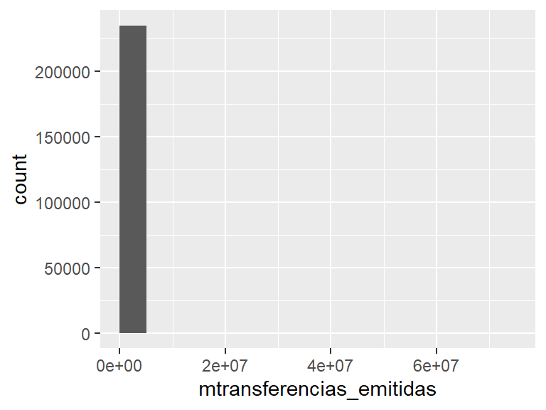

- Note that the following possible outlier values were detected: “464901.76”, “464908.88”, “465070.32”, “465180.68”, “465543”, “465804.16”, “465842.52”, “465873.31”, “465900.91”, “466668.43” (4110 additional values omitted).

## cextraccion_autoservicio

| Feature | Result |
| --- | --- |
| Variable type | integer |
| Number of missing obs. | 0 (0 %) |
| Number of unique values | 81 |
| Median | 0 |
| 1st and 3rd quartiles | 0; 3 |
| Min. and max. | 0; 215 |

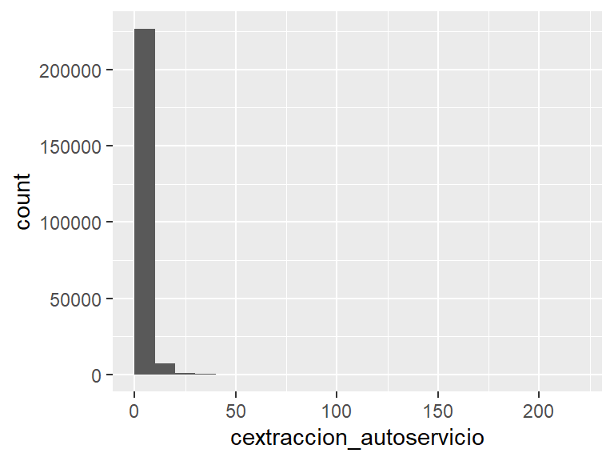

- Note that the following possible outlier values were detected: “108”, “120”, “140”, “201”, “215”.

## mextraccion_autoservicio

| Feature | Result |
| --- | --- |
| Variable type | numeric |
| Number of missing obs. | 0 (0 %) |
| Number of unique values | 4845 |
| Median | 0 |
| 1st and 3rd quartiles | 0; 23400 |
| Min. and max. | 0; 3159000 |

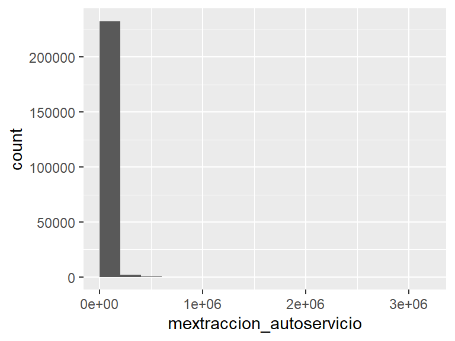

- Note that the following possible outlier values were detected: “733590”, “735930”, “737100”, “740610”, “748800”, “751608”, “754650”, “760052.47”, “760500”, “779220” (74 additional values omitted).

## ccheques_depositados

| Feature | Result |
| --- | --- |
| Variable type | integer |
| Number of missing obs. | 0 (0 %) |
| Number of unique values | 55 |
| Median | 0 |
| 1st and 3rd quartiles | 0; 0 |
| Min. and max. | 0; 158 |

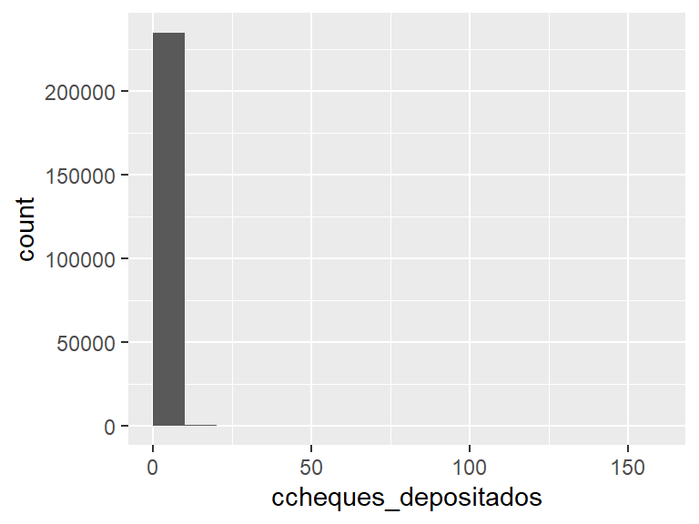

- Note that the following possible outlier values were detected: “1”, “2”, “3”, “4”, “5”, “6”, “7”, “8”, “9”, “10” (44 additional values omitted).

## mcheques_depositados

| Feature | Result |
| --- | --- |
| Variable type | numeric |
| Number of missing obs. | 0 (0 %) |
| Number of unique values | 6389 |
| Median | 0 |
| 1st and 3rd quartiles | 0; 0 |
| Min. and max. | 0; 26588250 |

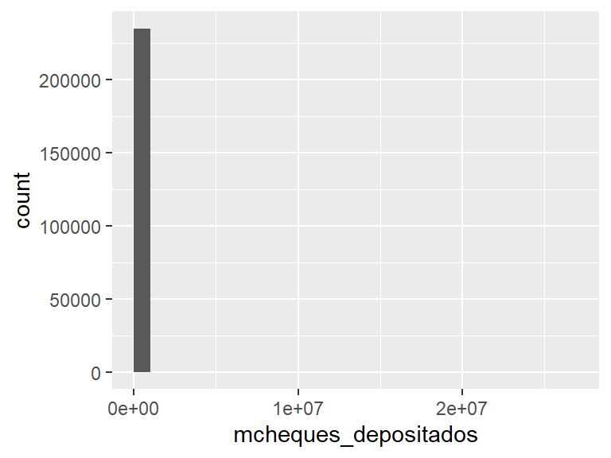

- Note that the following possible outlier values were detected: “3.51”, “11.7”, “117”, “409.13”, “410.67”, “526.5”, “585”, “624.78”, “649.87”, “702” (6378 additional values omitted).

## ccheques_emitidos

| Feature | Result |
| --- | --- |
| Variable type | integer |
| Number of missing obs. | 0 (0 %) |
| Number of unique values | 65 |
| Median | 0 |
| 1st and 3rd quartiles | 0; 0 |
| Min. and max. | 0; 125 |

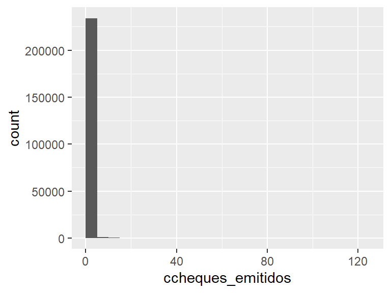

- Note that the following possible outlier values were detected: “1”, “2”, “3”, “4”, “5”, “6”, “7”, “8”, “9”, “10” (54 additional values omitted).

## mcheques_emitidos

| Feature | Result |
| --- | --- |
| Variable type | numeric |
| Number of missing obs. | 0 (0 %) |
| Number of unique values | 4736 |
| Median | 0 |
| 1st and 3rd quartiles | 0; 0 |
| Min. and max. | 0; 31210705.56 |

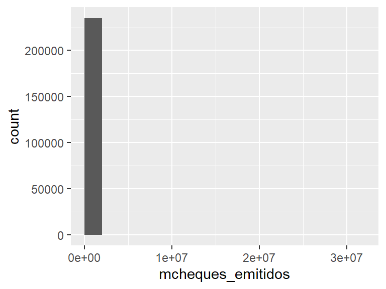

- Note that the following possible outlier values were detected: “1.17”, “23.4”, “92.41”, “175.5”, “286.49”, “351”, “584.39”, “697.32”, “702”, “735.93” (4725 additional values omitted).

## ccheques_depositados_rechazados

| Feature | Result |
| --- | --- |
| Variable type | integer |
| Number of missing obs. | 0 (0 %) |
| Number of unique values | 11 |
| Median | 0 |
| 1st and 3rd quartiles | 0; 0 |
| Min. and max. | 0; 12 |

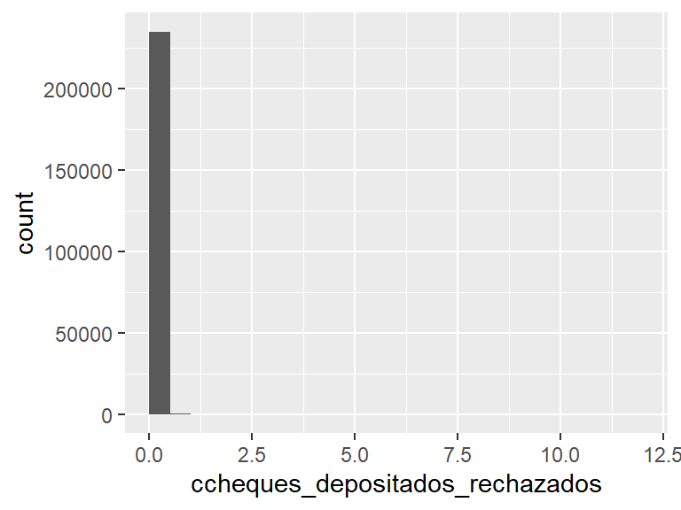

- Note that the following possible outlier values were detected: “1”, “2”, “3”, “4”, “5”, “6”, “7”, “8”, “10”, “12”.

## mcheques_depositados_rechazados

| Feature | Result |
| --- | --- |
| Variable type | numeric |
| Number of missing obs. | 0 (0 %) |
| Number of unique values | 335 |
| Median | 0 |
| 1st and 3rd quartiles | 0; 0 |
| Min. and max. | 0; 2106000 |

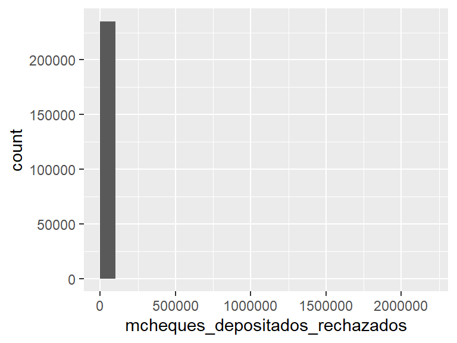

- Note that the following possible outlier values were detected: “893.99”, “2433.45”, “2691”, “2991.69”, “3357.9”, “3774.25”, “3832.92”, “4446”, “4680”, “4769.49” (324 additional values omitted).

## ccheques_emitidos_rechazados

| Feature | Result |
| --- | --- |
| Variable type | integer |
| Number of missing obs. | 0 (0 %) |
| Number of unique values | 13 |
| Median | 0 |
| 1st and 3rd quartiles | 0; 0 |
| Min. and max. | 0; 22 |

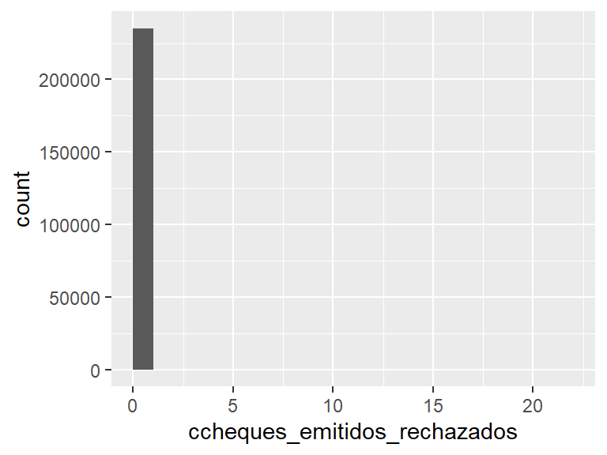

- Note that the following possible outlier values were detected: “1”, “2”, “3”, “4”, “5”, “6”, “7”, “8”, “11”, “14” (2 additional values omitted).

## mcheques_emitidos_rechazados

| Feature | Result |
| --- | --- |
| Variable type | numeric |
| Number of missing obs. | 0 (0 %) |
| Number of unique values | 325 |
| Median | 0 |
| 1st and 3rd quartiles | 0; 0 |
| Min. and max. | 0; 3393000 |

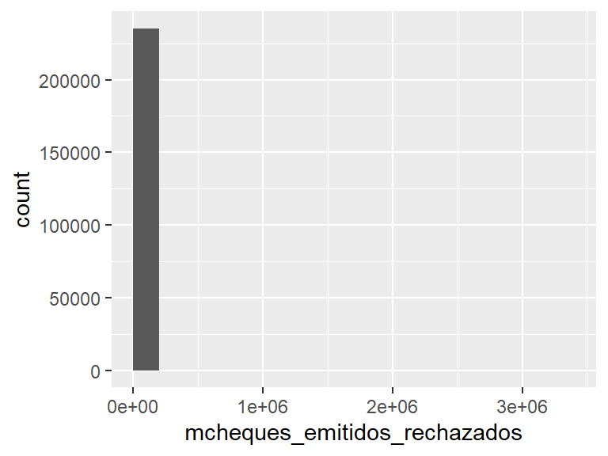

- Note that the following possible outlier values were detected: “153.7”, “175.5”, “1825.2”, “2340”, “2364.57”, “2452.32”, “2672.28”, “2693.34”, “2821.12”, “3159” (314 additional values omitted).

## tcallcenter

- Note that this variable is treated as a factor variable below, as it only takes a few unique values.

| Feature | Result |
| --- | --- |
| Variable type | integer |
| Number of missing obs. | 0 (0 %) |
| Number of unique values | 2 |
| Mode | “0” |
| Reference category | 0 |

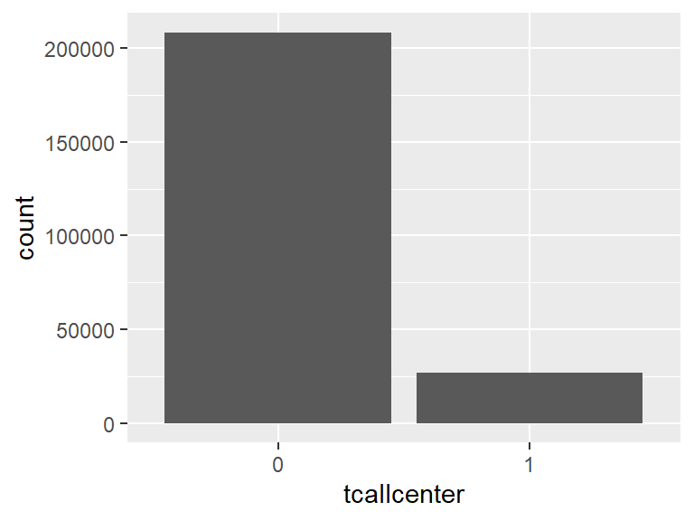

## ccallcenter_transacciones

| Feature | Result |
| --- | --- |
| Variable type | integer |
| Number of missing obs. | 0 (0 %) |
| Number of unique values | 57 |
| Median | 0 |
| 1st and 3rd quartiles | 0; 0 |
| Min. and max. | 0; 88 |

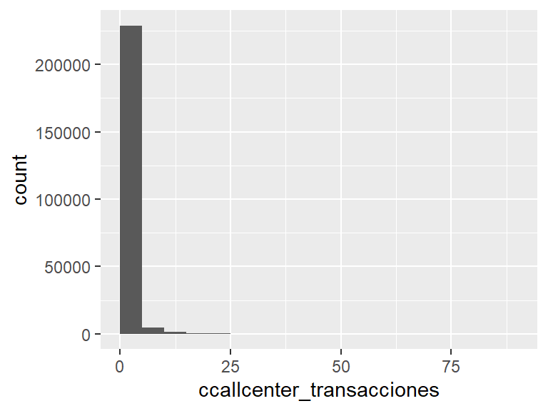

- The following suspected missing value codes enter as regular values: “88”.
- Note that the following possible outlier values were detected: “1”, “2”, “3”, “4”, “5”, “6”, “7”, “8”, “9”, “10” (46 additional values omitted).

## thomebanking

- Note that this variable is treated as a factor variable below, as it only takes a few unique values.

| Feature | Result |
| --- | --- |
| Variable type | integer |
| Number of missing obs. | 0 (0 %) |
| Number of unique values | 2 |
| Mode | “1” |
| Reference category | 0 |

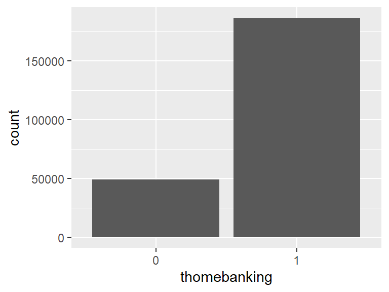

## chomebanking_transacciones

| Feature | Result |
| --- | --- |
| Variable type | integer |
| Number of missing obs. | 0 (0 %) |
| Number of unique values | 826 |
| Median | 30 |
| 1st and 3rd quartiles | 5; 78 |
| Min. and max. | 0; 10164 |

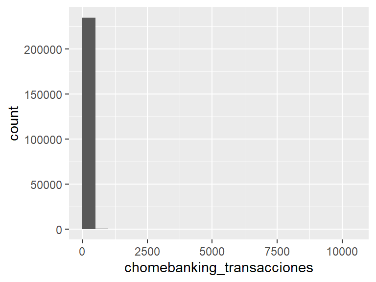

- Note that the following possible outlier values were detected: “449”, “450”, “451”, “452”, “453”, “454”, “455”, “456”, “457”, “458” (367 additional values omitted).

## ccajas_transacciones

- Note that this variable is treated as a factor variable below, as it only takes a few unique values.

| Feature | Result |
| --- | --- |
| Variable type | integer |
| Number of missing obs. | 0 (0 %) |
| Number of unique values | 2 |
| Mode | “0” |
| Reference category | 0 |

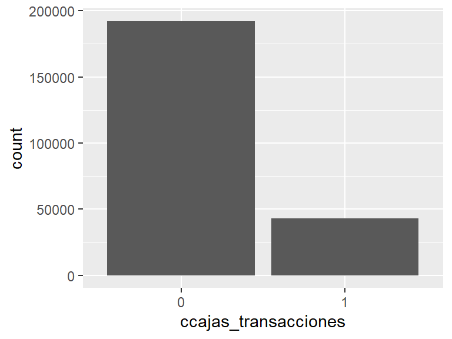

## ccajas_consultas

| Feature | Result |
| --- | --- |
| Variable type | integer |
| Number of missing obs. | 0 (0 %) |
| Number of unique values | 23 |
| Median | 0 |
| 1st and 3rd quartiles | 0; 0 |
| Min. and max. | 0; 31 |

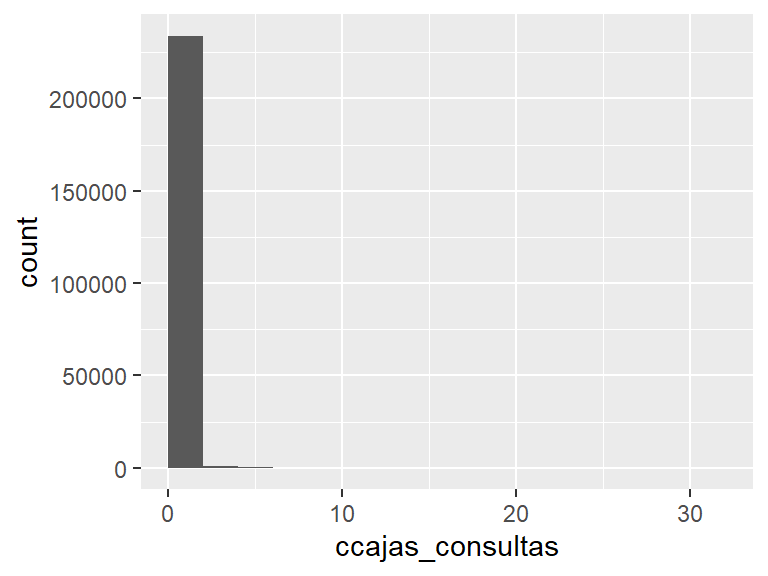

- Note that the following possible outlier values were detected: “1”, “2”, “3”, “4”, “5”, “6”, “7”, “8”, “9”, “10” (12 additional values omitted).

## ccajas_depositos

| Feature | Result |
| --- | --- |
| Variable type | integer |
| Number of missing obs. | 0 (0 %) |
| Number of unique values | 19 |
| Median | 0 |
| 1st and 3rd quartiles | 0; 0 |
| Min. and max. | 0; 27 |

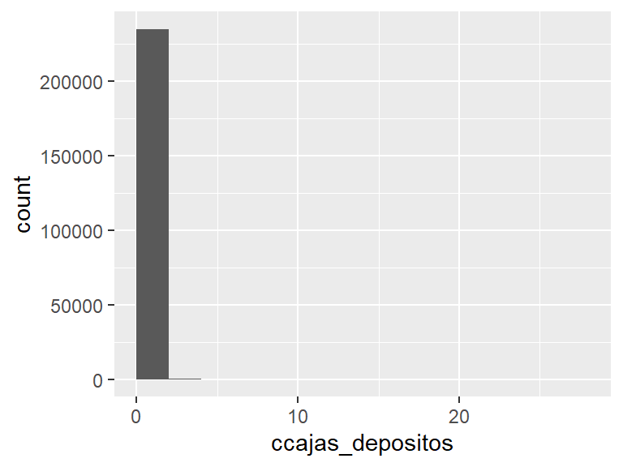

- Note that the following possible outlier values were detected: “1”, “2”, “3”, “4”, “5”, “6”, “7”, “8”, “9”, “10” (8 additional values omitted).

## ccajas_extracciones

| Feature | Result |
| --- | --- |
| Variable type | integer |
| Number of missing obs. | 0 (0 %) |
| Number of unique values | 11 |
| Median | 0 |
| 1st and 3rd quartiles | 0; 0 |
| Min. and max. | 0; 17 |

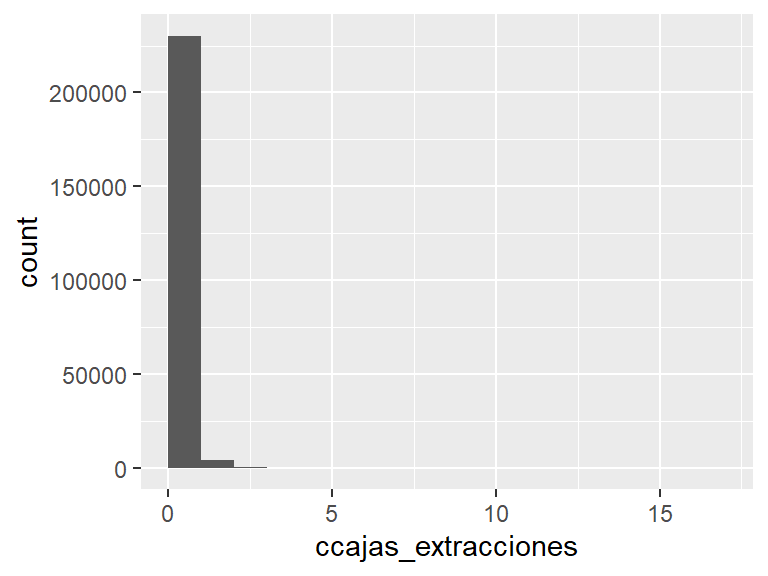

- Note that the following possible outlier values were detected: “1”, “2”, “3”, “4”, “5”, “6”, “7”, “8”, “15”, “17”.

## ccajas_otras

| Feature | Result |
| --- | --- |
| Variable type | integer |
| Number of missing obs. | 0 (0 %) |
| Number of unique values | 28 |
| Median | 0 |
| 1st and 3rd quartiles | 0; 0 |
| Min. and max. | 0; 82 |

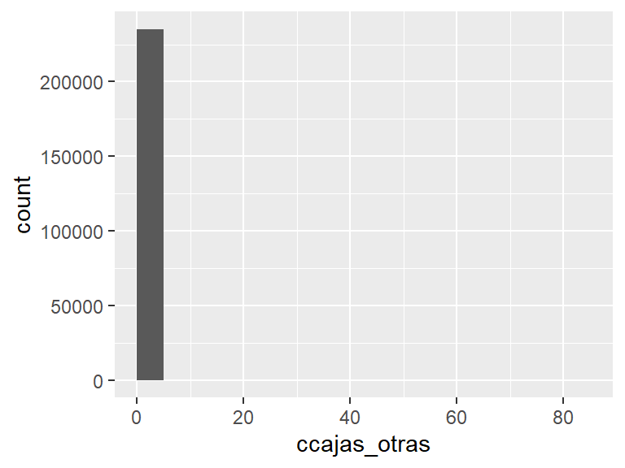

- Note that the following possible outlier values were detected: “1”, “2”, “3”, “4”, “5”, “6”, “7”, “8”, “9”, “10” (17 additional values omitted).

## catm_trx

| Feature | Result |
| --- | --- |
| Variable type | integer |
| Number of missing obs. | 0 (0 %) |
| Number of unique values | 81 |
| Median | 0 |
| 1st and 3rd quartiles | 0; 2 |
| Min. and max. | 0; 215 |

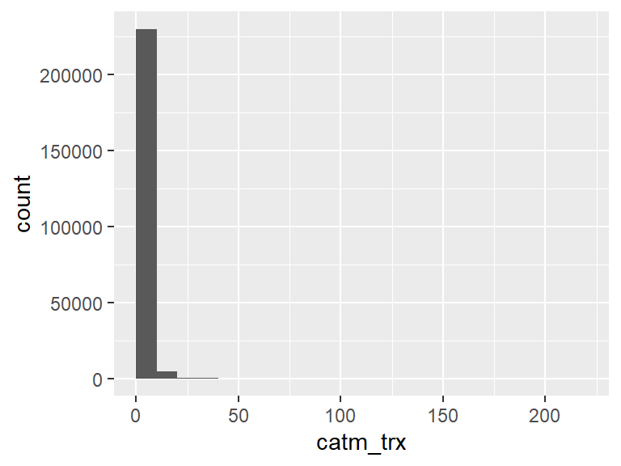

- Note that the following possible outlier values were detected: “64”, “67”, “69”, “70”, “72”, “74”, “76”, “78”, “83”, “85” (8 additional values omitted).

## matm

| Feature | Result |
| --- | --- |
| Variable type | numeric |
| Number of missing obs. | 0 (0 %) |
| Number of unique values | 4241 |
| Median | 0 |
| 1st and 3rd quartiles | 0; 17550 |
| Min. and max. | 0; 3159000 |

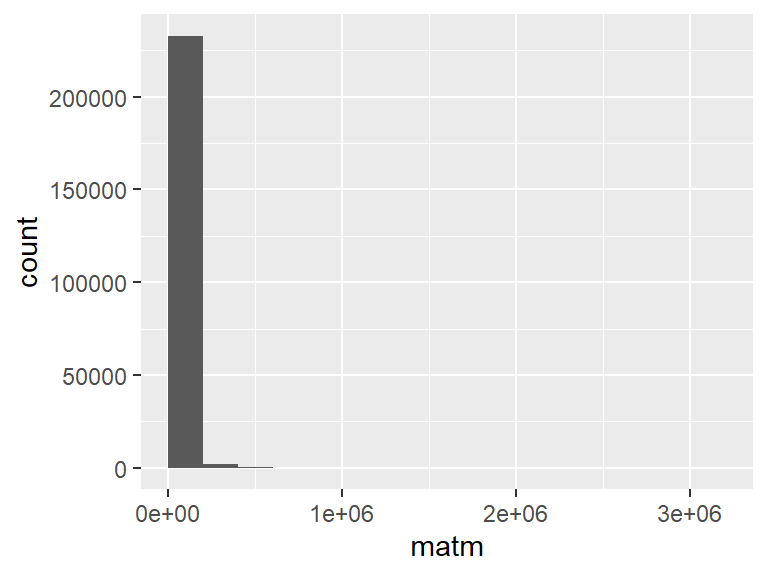

- Note that the following possible outlier values were detected: “546390”, “547560”, “548203.5”, “549900”, “552240”, “552573.45”, “554913.45”, “555750”, “558090”, “560430” (153 additional values omitted).

## catm_trx_other

| Feature | Result |
| --- | --- |
| Variable type | integer |
| Number of missing obs. | 0 (0 %) |
| Number of unique values | 43 |
| Median | 0 |
| 1st and 3rd quartiles | 0; 0 |
| Min. and max. | 0; 46 |

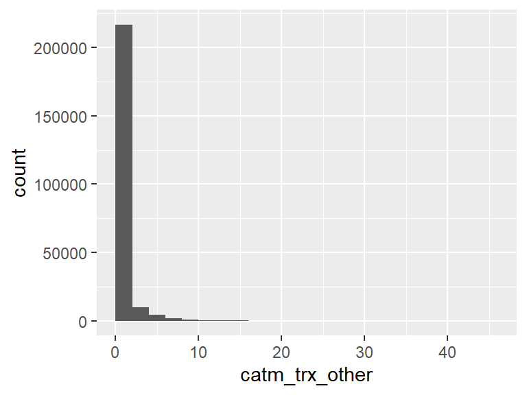

- Note that the following possible outlier values were detected: “1”, “2”, “3”, “4”, “5”, “6”, “7”, “8”, “9”, “10” (32 additional values omitted).

## matm_other

| Feature | Result |
| --- | --- |
| Variable type | numeric |
| Number of missing obs. | 0 (0 %) |
| Number of unique values | 888 |
| Median | 0 |
| 1st and 3rd quartiles | 0; 0 |
| Min. and max. | 0; 588223.35 |

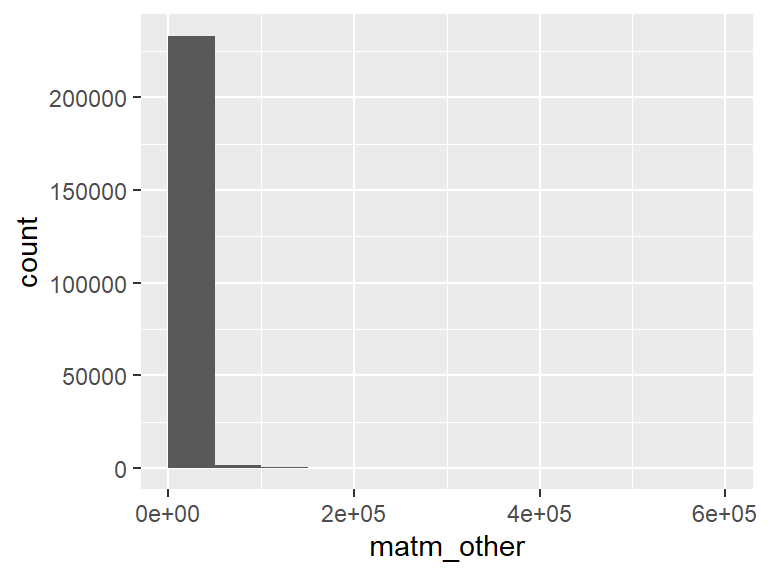

- Note that the following possible outlier values were detected: “117”, “175.5”, “234”, “351”, “468”, “585”, “702”, “819”, “936”, “1053” (877 additional values omitted).

## ctrx_quarter

| Feature | Result |
| --- | --- |
| Variable type | integer |
| Number of missing obs. | 0 (0 %) |
| Number of unique values | 899 |
| Median | 95 |
| 1st and 3rd quartiles | 54; 143 |
| Min. and max. | 0; 2878 |

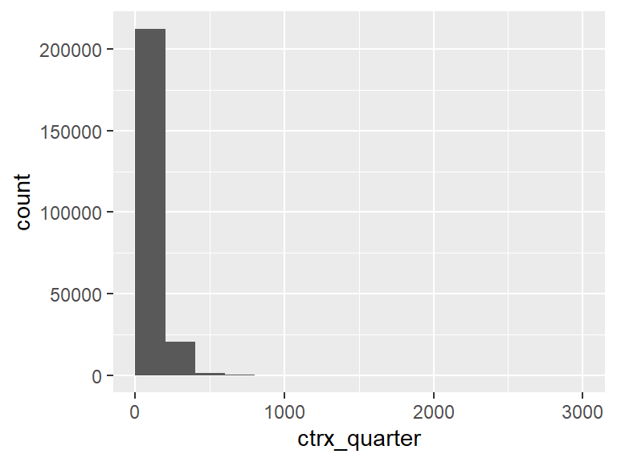

- Note that the following possible outlier values were detected: “335”, “336”, “337”, “338”, “339”, “340”, “341”, “342”, “343”, “344” (554 additional values omitted).

## tmobile_app

- Note that this variable is treated as a factor variable below, as it only takes a few unique values.

| Feature | Result |
| --- | --- |
| Variable type | integer |
| Number of missing obs. | 0 (0 %) |
| Number of unique values | 2 |
| Mode | “1” |
| Reference category | 0 |

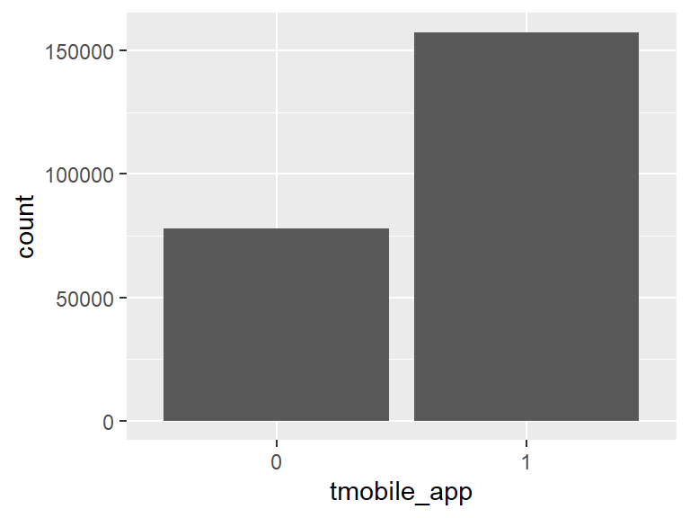

## cmobile_app_trx

| Feature | Result |
| --- | --- |
| Variable type | integer |
| Number of missing obs. | 0 (0 %) |
| Number of unique values | 646 |
| Median | 15 |
| 1st and 3rd quartiles | 0; 56 |
| Min. and max. | 0; 2699 |

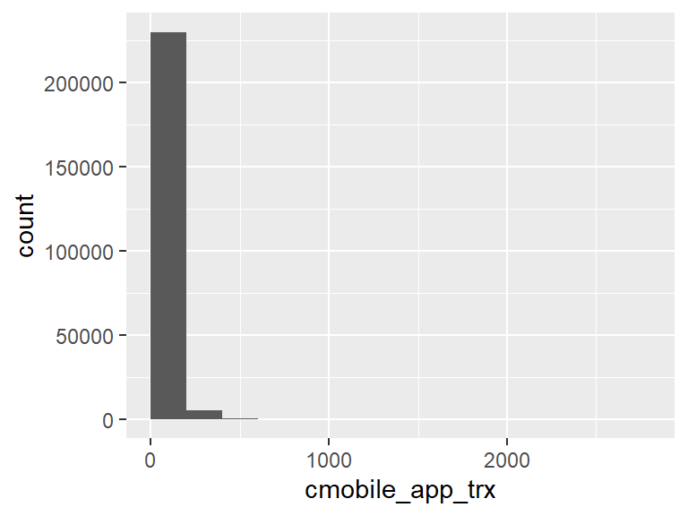

- Note that the following possible outlier values were detected: “479”, “480”, “481”, “482”, “484”, “485”, “486”, “487”, “488”, “489” (159 additional values omitted).

## Master_delinquency

- Note that this variable is treated as a factor variable below, as it only takes a few unique values.

| Feature | Result |
| --- | --- |
| Variable type | integer |
| Number of missing obs. | 22138 (9.41 %) |
| Number of unique values | 2 |
| Mode | “0” |
| Reference category | 0 |

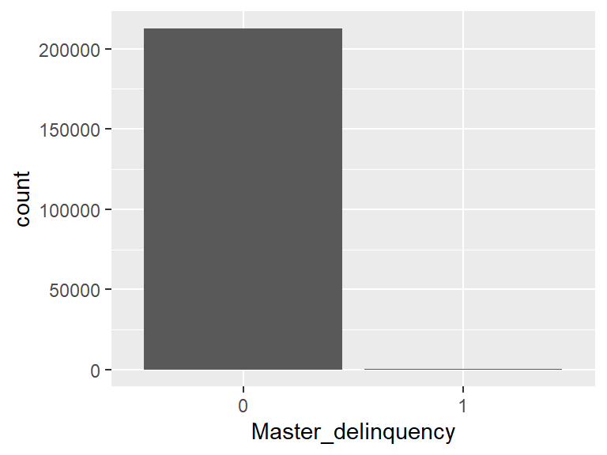

## Master_status

- Note that this variable is treated as a factor variable below, as it only takes a few unique values.

| Feature | Result |
| --- | --- |
| Variable type | integer |
| Number of missing obs. | 22138 (9.41 %) |
| Number of unique values | 4 |
| Mode | “0” |
| Reference category | 0 |

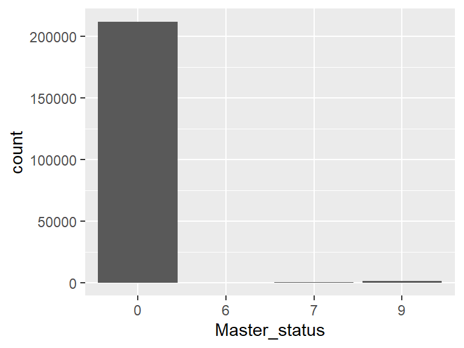

- The following suspected missing value codes enter as regular values: “9”.

## Master_mfinanciacion_limite

| Feature | Result |
| --- | --- |
| Variable type | numeric |
| Number of missing obs. | 22138 (9.41 %) |
| Number of unique values | 188 |
| Median | 176904 |
| 1st and 3rd quartiles | 88452; 427885.7 |
| Min. and max. | 0; 121903791.84 |

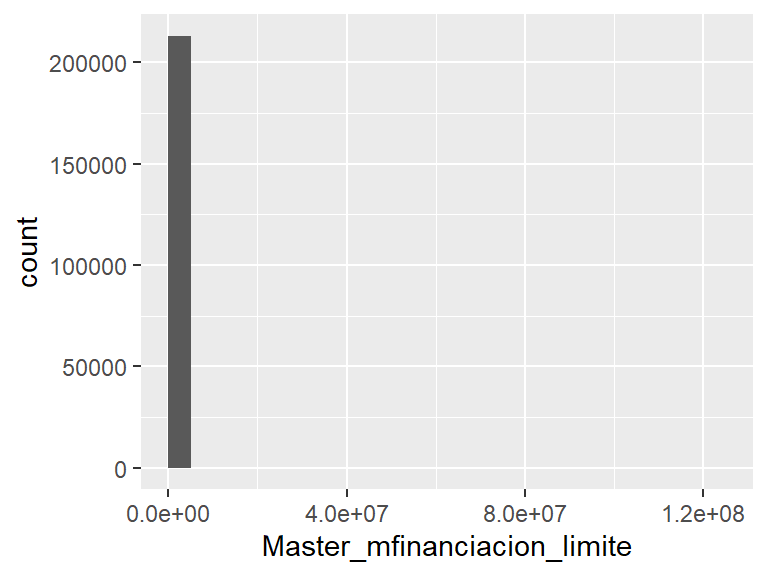

- Note that the following possible outlier values were detected: “0”, “737.1”, “884.52”, “1031.94”, “1179.36”, “1326.78”, “1474.2”, “1547.91”, “1769.04”, “2063.88” (57 additional values omitted).

## Master_Fvencimiento

| Feature | Result |
| --- | --- |
| Variable type | integer |
| Number of missing obs. | 22138 (9.41 %) |
| Number of unique values | 167 |
| Median | -880 |
| 1st and 3rd quartiles | -1521; -637 |
| Min. and max. | -2914360; 6303 |

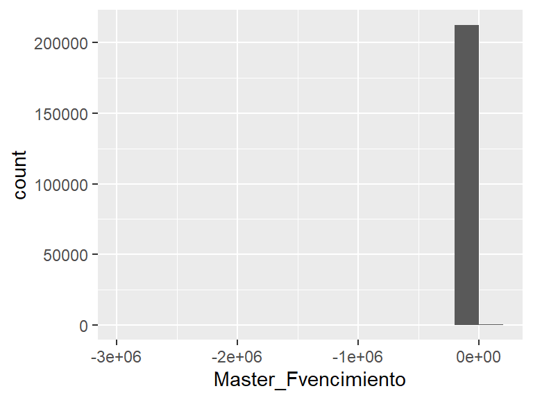

- Note that the following possible outlier values were detected: “-2914360”, “-303”, “-272”, “-242”, “-211”, “-181”, “-150”, “-122”, “-91”, “-60” (93 additional values omitted).

## Master_Finiciomora

| Feature | Result |
| --- | --- |
| Variable type | integer |
| Number of missing obs. | 234929 (99.82 %) |
| Number of unique values | 12 |
| Median | 9 |
| 1st and 3rd quartiles | 2; 9 |
| Min. and max. | 0; 135 |

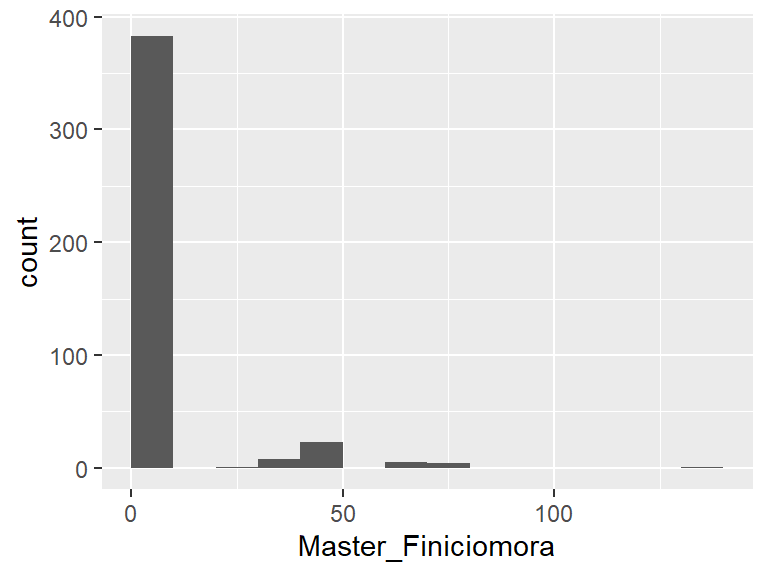

- Note that the following possible outlier values were detected: “29”, “37”, “41”, “43”, “63”, “65”, “72”, “135”.

## Master_msaldototal

| Feature | Result |
| --- | --- |
| Variable type | numeric |
| Number of missing obs. | 22138 (9.41 %) |
| Number of unique values | 84331 |
| Median | 0 |
| 1st and 3rd quartiles | 0; 4584.08 |
| Min. and max. | -1060829.83; 2632169.6 |

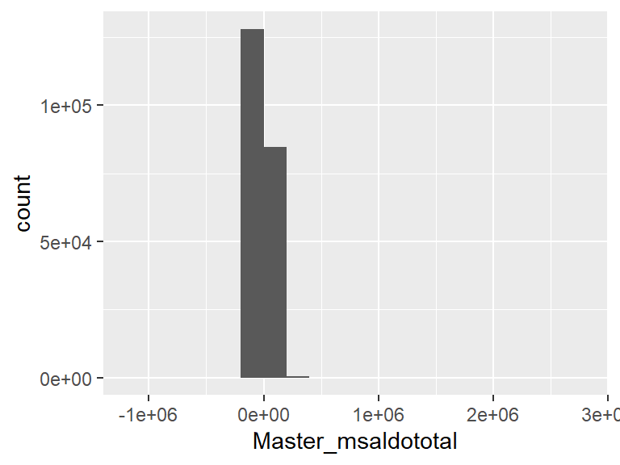

- Note that the following possible outlier values were detected: “-1060829.83”, “-872310.62”, “-671502.33”, “-648313.83”, “-594757.29”, “-585325.7”, “-518430.77”, “-517329.92”, “-478877.49”, “-469123.71” (5567 additional values omitted).

## Master_msaldopesos

| Feature | Result |
| --- | --- |
| Variable type | numeric |
| Number of missing obs. | 22138 (9.41 %) |
| Number of unique values | 83885 |
| Median | 0 |
| 1st and 3rd quartiles | 0; 4523.63 |
| Min. and max. | -1060829.83; 2632169.6 |

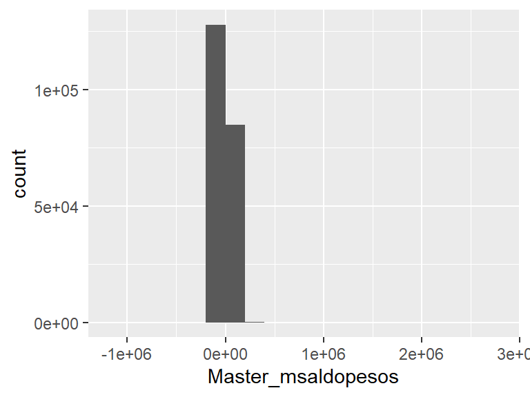

- Note that the following possible outlier values were detected: “-1060829.83”, “-648313.83”, “-597520.2”, “-522837.66”, “-517329.92”, “-478877.49”, “-410433.55”, “-398908.96”, “-393681.98”, “-378711.11” (4840 additional values omitted).

## Master_msaldodolares

| Feature | Result |
| --- | --- |
| Variable type | numeric |
| Number of missing obs. | 22138 (9.41 %) |
| Number of unique values | 5169 |
| Median | 0 |
| 1st and 3rd quartiles | 0; 0 |
| Min. and max. | -691794.75; 1289406.99 |

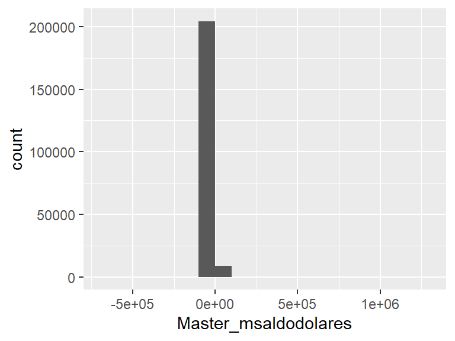

- Note that the following possible outlier values were detected: “-691794.75”, “-587330.48”, “-527922.98”, “-481006.14”, “-409380.6”, “-335572.81”, “-333482.19”, “-329605.39”, “-324959.2”, “-258939.27” (5158 additional values omitted).

## Master_mconsumospesos

| Feature | Result |
| --- | --- |
| Variable type | numeric |
| Number of missing obs. | 143687 (61.05 %) |
| Number of unique values | 51531 |
| Median | 2116.53 |
| 1st and 3rd quartiles | 0; 10195.61 |
| Min. and max. | -34016.87; 2200042.55 |

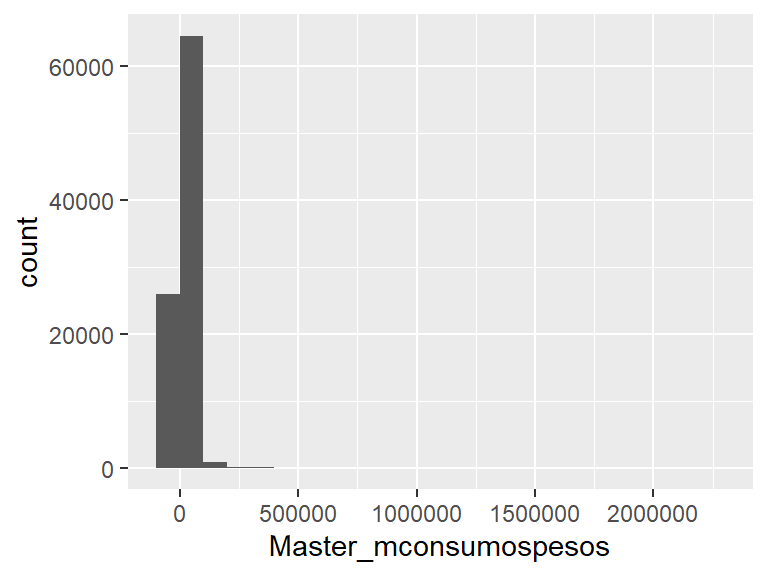

- Note that the following possible outlier values were detected: “-34016.87”, “-15711.34”, “-14550.35”, “-12355.2”, “-12252.39”, “-11265.05”, “-10878.89”, “-10670.4”, “-10582.76”, “-10041.79” (1015 additional values omitted).

## Master_mconsumosdolares

| Feature | Result |
| --- | --- |
| Variable type | numeric |
| Number of missing obs. | 143687 (61.05 %) |
| Number of unique values | 3003 |
| Median | 0 |
| 1st and 3rd quartiles | 0; 0 |
| Min. and max. | 0; 16809.41 |

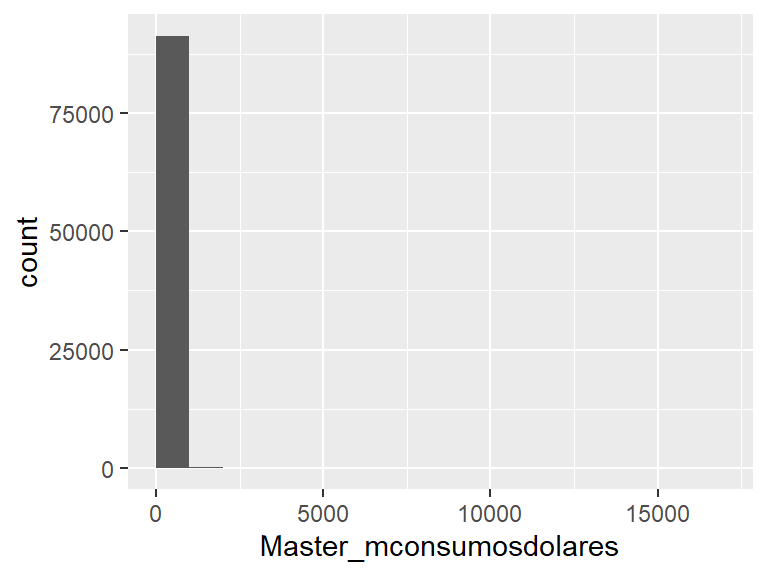

- Note that the following possible outlier values were detected: “0.01”, “0.23”, “0.37”, “0.38”, “0.45”, “0.47”, “0.52”, “0.58”, “0.6”, “0.62” (2992 additional values omitted).

## Master_mlimitecompra

| Feature | Result |
| --- | --- |
| Variable type | numeric |
| Number of missing obs. | 22138 (9.41 %) |
| Number of unique values | 154 |
| Median | 196560 |
| 1st and 3rd quartiles | 98280; 475497.52 |
| Min. and max. | 982.8; 21411000 |

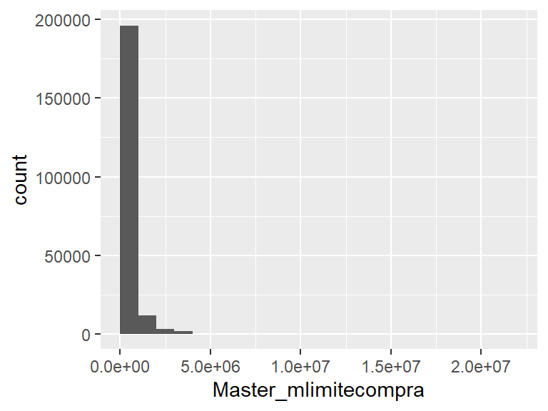

- Note that the following possible outlier values were detected: “982.8”, “1228.5”, “1474.2”, “1719.9”, “1965.6”, “2457”, “2948.4”, “3439.8”, “3790.8”, “4738.5” (34 additional values omitted).

## Master_madelantopesos

| Feature | Result |
| --- | --- |
| Variable type | numeric |
| Number of missing obs. | 143687 (61.05 %) |
| Number of unique values | 57 |
| Median | 0 |
| 1st and 3rd quartiles | 0; 0 |
| Min. and max. | 0; 18007.54 |

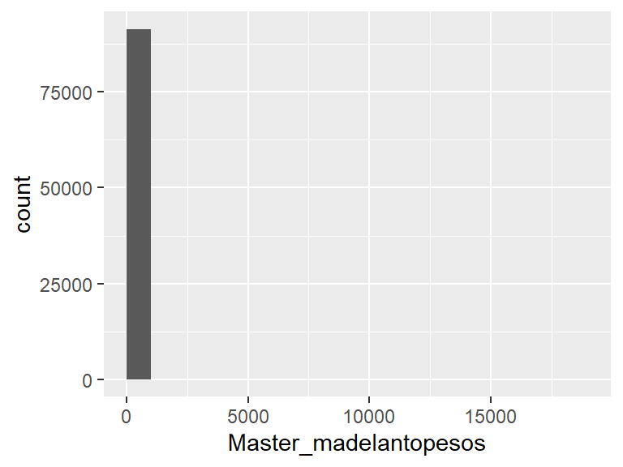

- Note that the following possible outlier values were detected: “585”, “819”, “1170”, “1521”, “1755”, “2340”, “2574”, “2925”, “3159”, “3510” (46 additional values omitted).

## Master_madelantodolares

| Feature | Result |
| --- | --- |
| Variable type | numeric |
| Number of missing obs. | 143687 (61.05 %) |
| Number of unique values | 10 |
| Median | 0 |
| 1st and 3rd quartiles | 0; 0 |
| Min. and max. | 0; 236.9 |

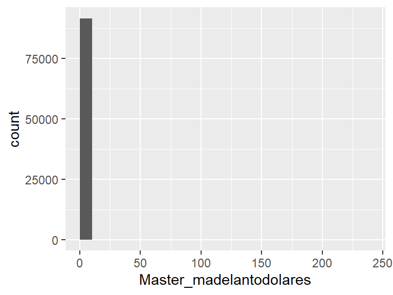

- Note that the following possible outlier values were detected: “141.06”, “195.48”, “209.05”, “209.82”, “210”, “214.6”, “214.78”, “236.16”, “236.9”.

## Master_fultimo_cierre

| Feature | Result |
| --- | --- |
| Variable type | integer |
| Number of missing obs. | 22195 (9.43 %) |
| Number of unique values | 136 |
| Median | 0 |
| 1st and 3rd quartiles | 0; 0 |
| Min. and max. | 0; 4830 |

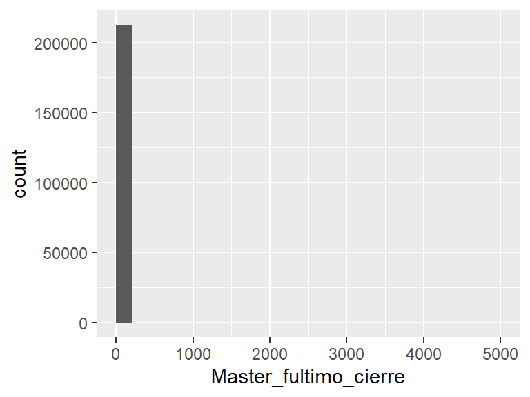

- Note that the following possible outlier values were detected: “7”, “14”, “21”, “35”, “42”, “49”, “63”, “70”, “91”, “98” (125 additional values omitted).

## Master_mpagado

| Feature | Result |
| --- | --- |
| Variable type | numeric |
| Number of missing obs. | 22138 (9.41 %) |
| Number of unique values | 9470 |
| Median | 0 |
| 1st and 3rd quartiles | 0; 0 |
| Min. and max. | 0; 1037085.58 |

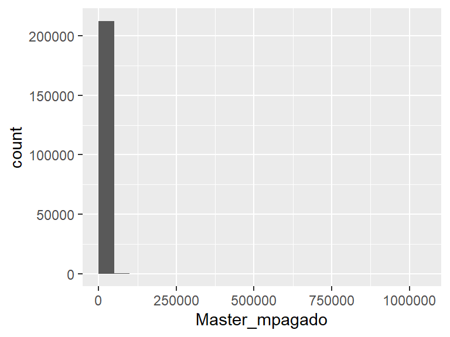

- Note that the following possible outlier values were detected: “0.09”, “0.46”, “0.69”, “0.78”, “0.8”, “1.02”, “1.17”, “1.29”, “1.42”, “1.54” (9459 additional values omitted).

## Master_mpagospesos

| Feature | Result |
| --- | --- |
| Variable type | numeric |
| Number of missing obs. | 143687 (61.05 %) |
| Number of unique values | 65868 |
| Median | -5027.16 |
| 1st and 3rd quartiles | -14278.08; -1015.62 |
| Min. and max. | -2577689.03; 301821.93 |

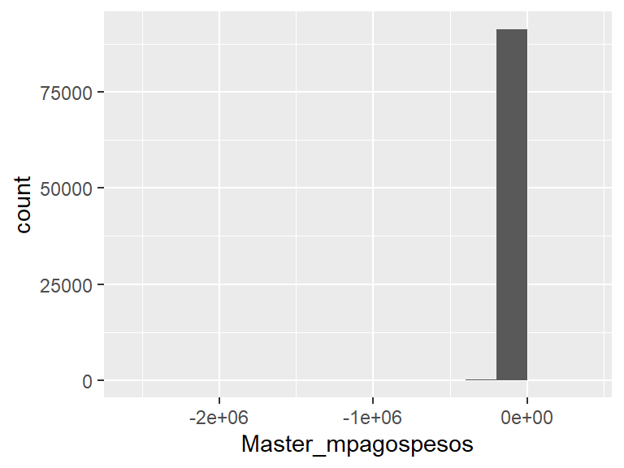

- Note that the following possible outlier values were detected: “-2577689.03”, “-2281032”, “-2160099.36”, “-2094183”, “-1293611.57”, “-1238243.33”, “-1203926.4”, “-1107703.66”, “-1034374.18”, “-973990.68” (1272 additional values omitted).

## Master_mpagosdolares

| Feature | Result |
| --- | --- |
| Variable type | numeric |
| Number of missing obs. | 143687 (61.05 %) |
| Number of unique values | 2385 |
| Median | 0 |
| 1st and 3rd quartiles | 0; 0 |
| Min. and max. | 0; 21684.04 |

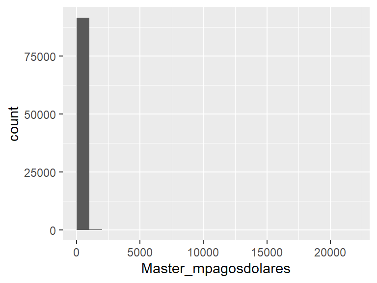

- Note that the following possible outlier values were detected: “0.01”, “0.02”, “0.03”, “0.04”, “0.08”, “0.09”, “0.1”, “0.11”, “0.12”, “0.14” (2374 additional values omitted).

## Master_fechaalta

| Feature | Result |
| --- | --- |
| Variable type | integer |
| Number of missing obs. | 22138 (9.41 %) |
| Number of unique values | 4666 |
| Median | 2120 |
| 1st and 3rd quartiles | 871; 3690 |
| Min. and max. | 1; 7420 |

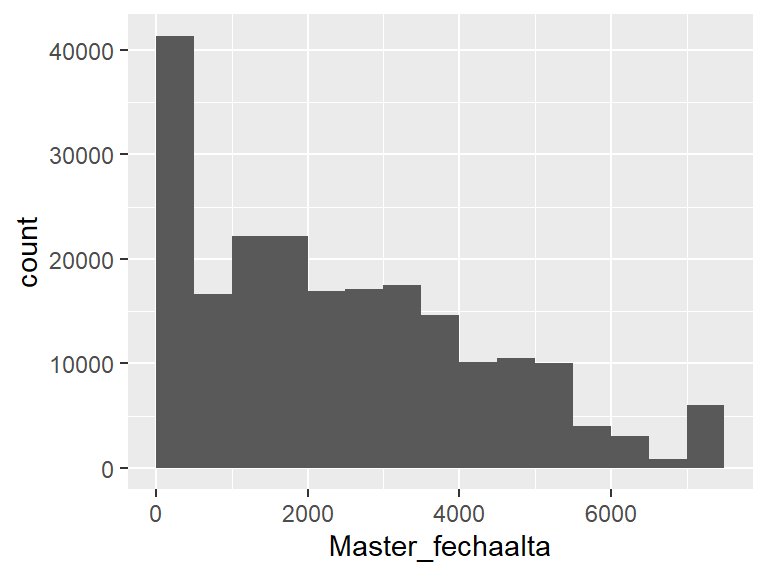